# Executive Summary

Based on the analysis, the airline should make efforts to understand and improve the following areas in order to increase overall satisfaction.

## Departure and Arrival Delays

Although, there is no Linear Dependency between Departure and Arrival Delay and Flight Distance, Departure and Arrival Time Convenience has a significant impact on customers’ Overall Satisfaction. Since the majority of the instances of Departure and Arrival Delay are small (range between 0 -15 minutes), as seen in Figures 2.3 and 2.4, it would be worthwhile for the airline to investigate the causes of these short delays. Long delays could be caused by something out of control by their airline, such as weather, but short delays could be caused by issues the airline could prevent. Such examples include air traffic organization (by working more closely with the airports), travel density (how many airline flights are back-to-back scheduled), regular schedules for preventative maintenance.

Finally, it would be wise to invest in better in-flight service for long haul flights. Although Departure Delays can affect customer satisfaction on the longer flights, exceptional in-flight service over the course of the journey has a greater impact on overall passenger satisfaction on longer flights.

## Seat Comfort

Knowing from Figure 2.2 that Short Haul Flights make up the next majority of flights after Medium Haul, it is worthwhile to understand that passengers on Short Haul flights are more affected by Seat Comfort than by Departure Delays. Additionally, male passengers are slightly more dissatisfied from Seat Comfort than Female Passengers. From the association rules derived (see full set of association rules derived in link provided in Appendix Section A4), it can be seen that Senior Male passengers are frequently on Short Haul Flights. Ensuring more comfortable seats, especially on short haul flights, will lead to more Overall Satisfaction from passengers on Short Haul flights as well as Male Passengers.

## Gate Location

As seen from Figure 7.2, Middle Age Passengers are slightly more satisfied than dissatisfied with gate location. However, more steps could be done to increase satisfaction in this area. A survey could be done to study the following about passenger satisfaction with gate location:

Are gate locations between connecting flights too far apart? Perhaps passengers feel stressed running to a far gate location during a short layover. Is the gate close enough to restrooms or food services? Are there enough outlets at the gate? Are the chairs comfortable enough?

Understanding the factors in satisfaction with gate location can help the airline make improvements, including working with the airport where necessary to increase passenger satisfaction in this area.

## Customer Rentention

As seen from Figure 7.3, First-time customers feel vastly less satisfied with the airline then they feel satisfied. There are also significantly less First-time customers than Returning customers.

It could be that first-time customers had higher expectations when trying out the airline. This could be due to various factors. Perhaps the customer chose the airline due to the price compared with other airlines, or they were motivated by an advertisement. It would be important to understand what expectations First-time customers had before first using the airline so that improvements could be made either in flight services or in advertising to better angle towards customers whose needs match the quality of services the airline offers.

Returning customers appear to be more evenly split between being satisfied and being dissatisfied. Perhaps returning customers have better expectations of the airline services after flying with the airline previously, leading them to better appreciate the airline services offered. However, still more could be done to address returning customers’ expectations and needs. Asking returning customers what their expectations are of the airline can also provide valuable information so that the airline can retain more of their loyal customers.

## Personal versus Business Travel

Figure 7.4 indicates a similar trend in overall satisfaction from business and personal travels as seen in first-time and returning customers. While the majority of passengers travelling for business are more satisfied than dissatisfied with the airline, the passengers travelling for personal reasons are vastly more dissatisfied.

This could be because business travelers travel more frequently, allowing them to enjoy more airline perks, such as better seating or paying for more in-flight entertainment, or they feel more comfortable spending money since their trip is more likely to be paid for by a third party. Business travelers could be more likely to travel alone, while personal travelers could be travelling with family members, causing them an external source of stress.

Although it would be difficult to control who accompanies passengers on their flights, it would be worthwhile for the airline to study what perks business travelers utilize on the airline to make their experience more enjoyable. If there are certain perks business travelers enjoy, perhaps the airline would benefit by advertising these perks to personal travelers, such as through discounts and promotions.

## Food and Drink

It can be seen from Figure 7.5 those passengers flying in Business class are more satisfied with their Food and Drink than passengers flying in Economy class. This could be because in-flight services, including food and drink, are purposely more catered to business class passengers than economy class passengers since that is the reason why customers in business class pay more money.

However, it might be worth a further study into why economy class passengers are more dissatisfied with their food and drink. If possible, the airline can still offer economy class passengers better food and drink options, even if for an additional fee. While in-flight, offering Economy Passengers the same food and drink options as the Business Class are presented, but for an additional fee, may lead to increased satisfaction with Economy class passengers.

## Check—in Service and Baggage Handling

It is clear from Figure 7.6 there is a relationship between check-in service and baggage handling. Passengers who rated satisfaction with check-in Service a 3 or higher, are also more likely to be more satisfied with baggage handling.

This could be due to the way the employees at Check-In process the passenger’s luggage impact how many bags are lost or misplaced during the flight. Additionally, perhaps there is overlap in the employees who handle check in as well as baggage handling. If these employees are trained to do better in one area, they might improve in another area such as baggage handling.

Increasing the quality of employees who handle check-in service can have a direct positive impact on customer satisfaction with baggage handling.

# Detailed Analysis

## Data Preparation

### Import Statements

```python
from google.colab import drive
drive.mount('/content/drive')

from google.colab.data_table import DataTable
DataTable.max_columns = 30

import pandas as pd
import numpy as np
from numpy import NaN
from pandas import Series, DataFrame
import matplotlib.pyplot as plt
import seaborn as sns

from mlxtend.preprocessing import TransactionEncoder
from mlxtend.frequent_patterns import apriori
from mlxtend.frequent_patterns import association_rules

from sklearn.linear_model import LinearRegression
from sklearn.linear_model import LogisticRegression
from sklearn.model_selection import KFold
from sklearn.model_selection import train_test_split
from sklearn.metrics import classification_report

import statsmodels.api as sm


from scipy.stats import chi2, chi2_contingency

from sklearn import preprocessing
```

### Load Data

#### Original Dataset

```python
df = pd.read_csv('/content/drive/MyDrive/CS773/Project/v2/airline_passenger_satisfaction-1.csv')
df.head(11)
```

|  | ID | Gender | Age | Customer Type | Type of Travel | Class | Flight Distance | Departure Delay | Arrival Delay | Departure and Arrival Time Convenience | ... | On-board Service | Seat Comfort | Leg Room Service | Cleanliness | Food and Drink | In-flight Service | In-flight Wifi Service | In-flight Entertainment | Baggage Handling | Satisfaction |
| --- | --- | --- | --- | --- | --- | --- | --- | --- | --- | --- | --- | --- | --- | --- | --- | --- | --- | --- | --- | --- | --- |
| 0 | 1 | Male | 48 | First-time | Business | Business | 821 | 2 | 5.0 | 3 | ... | 3 | 5 | 2 | 5 | 5 | 5 | 3 | 5 | 5 | Neutral or Dissatisfied |
| 1 | 2 | Female | 35 | Returning | Business | Business | 821 | 26 | 39.0 | 2 | ... | 5 | 4 | 5 | 5 | 3 | 5 | 2 | 5 | 5 | Satisfied |
| 2 | 3 | Male | 41 | Returning | Business | Business | 853 | 0 | 0.0 | 4 | ... | 3 | 5 | 3 | 5 | 5 | 3 | 4 | 3 | 3 | Satisfied |
| 3 | 4 | Male | 50 | Returning | Business | Business | 1905 | 0 | 0.0 | 2 | ... | 5 | 5 | 5 | 4 | 4 | 5 | 2 | 5 | 5 | Satisfied |
| 4 | 5 | Female | 49 | Returning | Business | Business | 3470 | 0 | 1.0 | 3 | ... | 3 | 4 | 4 | 5 | 4 | 3 | 3 | 3 | 3 | Satisfied |
| 5 | 6 | Male | 43 | Returning | Business | Business | 3788 | 0 | 0.0 | 4 | ... | 4 | 4 | 4 | 3 | 3 | 4 | 4 | 4 | 4 | Satisfied |
| 6 | 7 | Male | 43 | Returning | Business | Business | 1963 | 0 | 0.0 | 3 | ... | 5 | 5 | 5 | 4 | 5 | 5 | 3 | 5 | 5 | Satisfied |
| 7 | 8 | Female | 60 | Returning | Business | Business | 853 | 0 | 3.0 | 3 | ... | 3 | 4 | 4 | 4 | 4 | 3 | 4 | 3 | 3 | Satisfied |
| 8 | 9 | Male | 50 | Returning | Business | Business | 2607 | 0 | 0.0 | 1 | ... | 4 | 3 | 4 | 3 | 3 | 4 | 4 | 4 | 4 | Neutral or Dissatisfied |
| 9 | 10 | Female | 38 | Returning | Business | Business | 2822 | 13 | 0.0 | 2 | ... | 5 | 4 | 5 | 4 | 2 | 5 | 2 | 5 | 5 | Satisfied |
| 10 | 11 | Female | 28 | First-time | Business | Business | 821 | 0 | 5.0 | 1 | ... | 2 | 2 | 5 | 2 | 2 | 4 | 1 | 2 | 3 | Neutral or Dissatisfied |

11 rows × 24 columns

### Prinicipal Component Datasets

```python
df_pcas = pd.read_csv('/content/drive/MyDrive/CS773/Project/v2/airline_passenger_satisfaction-1_PCAS.csv')
df_pcas.head(11)
```

|  | PCAS | Satisfaction |
| --- | --- | --- |
| 0 | -2.237027 | Neutral or Dissatisfied |
| 1 | -2.314186 | Satisfied |
| 2 | -1.692443 | Satisfied |
| 3 | -2.327453 | Satisfied |
| 4 | -0.814370 | Satisfied |
| 5 | -1.437932 | Satisfied |
| 6 | -3.113272 | Satisfied |
| 7 | -0.680189 | Satisfied |
| 8 | 0.149749 | Neutral or Dissatisfied |
| 9 | -2.161782 | Satisfied |
| 10 | 2.678023 | Neutral or Dissatisfied |

```python
df_pcas3 = pd.read_csv('/content/drive/MyDrive/CS773/Project/v2/airline_passenger_satisfaction-1_PCAS_3.csv')
df_pcas3.head(11)
```

|  | PCAS1 | PCAS2 | PCAS3 | Satisfaction |
| --- | --- | --- | --- | --- |
| 0 | -2.237027 | -0.845632 | -0.669553 | Neutral or Dissatisfied |
| 1 | -2.314186 | -1.669230 | 1.128723 | Satisfied |
| 2 | -1.692443 | 1.156659 | -2.177561 | Satisfied |
| 3 | -2.327453 | -1.886207 | 0.993394 | Satisfied |
| 4 | -0.814370 | 0.101744 | -1.446842 | Satisfied |
| 5 | -1.437932 | 1.553018 | 0.176401 | Satisfied |
| 6 | -3.113272 | -0.718743 | 0.728514 | Satisfied |
| 7 | -0.680189 | 1.183753 | -1.203822 | Satisfied |
| 8 | 0.149749 | -1.637149 | 0.983705 | Neutral or Dissatisfied |
| 9 | -2.161782 | -0.261973 | 1.507414 | Satisfied |
| 10 | 2.678023 | -1.297603 | 1.274148 | Neutral or Dissatisfied |

## Step 1. Statistics on Departure Delay and Arrival Delay

Essentially, most of the instances where Departure Delay and Arrival Delay occur are for short periods of time. It can be seen from both the Histogram and Box and Whisker Distribution Plots that both Departure Delay and Arrival Delay are positively skewed with most of the examples of Departure and Arrival Delay occurring with shorter delay times side with some outliers for longer delay times.

The instances for longer delay times might be due to reasons that are rare and often may be out of control of the airline, such as weather conditions. However, other reasons could be mechanical issues could cause longer delays if the mechanical problem takes some time to fix before the flight can take off.

It would be worthwhile to perform a further analysis on discovering the reasons of the shorter delays to see if there are easy solutions to minimize the amount of delay times even further, since the shorter delays compose of most of the instances.

From the covariance and correlation matrices between Departure Delay and Arrival Delay, it is easy to see that there is a positive linear relationship between Departure Delay and Arrival Delay. This makes sense: If there is a delay in Flight Departure, there will be a delay in the Flight Arrival. Hence, we can limit further analysis into understanding what causes Departure Delays, as understanding and addressing issues that cause Departure Delays will also help resolve Arrival Delays.

\

*Table 1.1 Summary of Statistics on Departure Delay (Minutes) and Arrival Delay (Minutes)*

[figure not shown]

*Table 1.2 Covariance Matrix of Departure Delay (Minutes) and Arrival Delay (Minutes)*

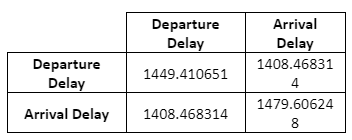

*Table 1.3 Correlation Matrix of Departure Delay (Minutes) and Arrival Delay (Minutes)*

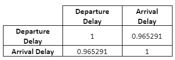

### Departure Delay Statistics

```python
print('\033[1m' + '--- i. Central Tendency Measures ---' + '\033[0m')

print("Mean of Departure Delay: " , df['Departure Delay'].mean())
print("Mode of Departure Delay: " , df['Departure Delay'].mode())
print("Median of Departure Delay: " , df['Departure Delay'].median())

print()

print('\033[1m' + '--- ii. The Spread (Standard Deviation) ---' + '\033[0m')

print("Spread (Std Dev) of Departure Delay: " , df['Departure Delay'].std())

print()

print('\033[1m' + '--- iii. Percentiles: the 10th, 50th, 75th and 90th percentiles  ---' + '\033[0m')

print("10th Percentile of Departure Delay: " , df['Departure Delay'].quantile(0.1))
print("50th Percentile of Departure Delay: " , df['Departure Delay'].quantile(0.5))
print("75th Percentile of Departure Delay: " , df['Departure Delay'].quantile(0.75))
print("90th Percentile of Departure Delay: " , df['Departure Delay'].quantile(0.90))

print()

print('\033[1m' + '--- iv. 1st quartile, 3rd quartile, and the median  ---' + '\033[0m')

print("1st Quartile of Departure Delay: " , df['Departure Delay'].quantile(0.25))
print("3rd Quartile of Departure Delay: " , df['Departure Delay'].quantile(0.75))
print("Median of Departure Delay: " , df['Departure Delay'].median())

print()

print('\033[1m' + '--- v. The Skewness  ---' + '\033[0m')

print("Skewness of Departure Delay: " , df['Departure Delay'].skew())
```

```
--- i. Central Tendency Measures ---
Mean of Departure Delay:  14.713712657838004
Mode of Departure Delay:  0    0
Name: Departure Delay, dtype: int64
Median of Departure Delay:  0.0

--- ii. The Spread (Standard Deviation) ---
Spread (Std Dev) of Departure Delay:  38.07112621503653

--- iii. Percentiles: the 10th, 50th, 75th and 90th percentiles  ---
10th Percentile of Departure Delay:  0.0
50th Percentile of Departure Delay:  0.0
75th Percentile of Departure Delay:  12.0
90th Percentile of Departure Delay:  44.0

--- iv. 1st quartile, 3rd quartile, and the median  ---
1st Quartile of Departure Delay:  0.0
3rd Quartile of Departure Delay:  12.0
Median of Departure Delay:  0.0

--- v. The Skewness  ---
Skewness of Departure Delay:  6.821980310173463
```

### Arrival Delay Statistics

```python
print('\033[1m' + '--- i. Central Tendency Measures ---' + '\033[0m')

print("Mean of Arrival Delay: " , df['Arrival Delay'].mean())
print("Mode of Arrival Delay: " , df['Arrival Delay'].mode())
print("Median of Arrival Delay: " , df['Arrival Delay'].median())

print()

print('\033[1m' + '--- ii. The Spread (Standard Deviation) ---' + '\033[0m')

print("Spread (Std Dev) of Arrival Delay: " , df['Arrival Delay'].std())

print()

print('\033[1m' + '--- iii. Percentiles: the 10th, 50th, 75th and 90th percentiles  ---' + '\033[0m')

print("10th Percentile of Arrival Delay: " , df['Arrival Delay'].quantile(0.1))
print("50th Percentile of Arrival Delay: " , df['Arrival Delay'].quantile(0.5))
print("75th Percentile of Arrival Delay: " , df['Arrival Delay'].quantile(0.75))
print("90th Percentile of Arrival Delay: " , df['Arrival Delay'].quantile(0.90))

print()

print('\033[1m' + '--- iv. 1st quartile, 3rd quartile, and the median  ---' + '\033[0m')

print("1st Quartile of Arrival Delay: " , df['Arrival Delay'].quantile(0.25))
print("3rd Quartile of Arrival Delay: " , df['Arrival Delay'].quantile(0.75))
print("Median Quartile of Arrival Delay: " , df['Arrival Delay'].median())

print()

print('\033[1m' + '--- v. The Skewness  ---' + '\033[0m')

print("Skewness of Arrival Delay: " , df['Arrival Delay'].skew())
```

```
--- i. Central Tendency Measures ---
Mean of Arrival Delay:  15.09112883918849
Mode of Arrival Delay:  0    0.0
Name: Arrival Delay, dtype: float64
Median of Arrival Delay:  0.0

--- ii. The Spread (Standard Deviation) ---
Spread (Std Dev) of Arrival Delay:  38.465650240119096

--- iii. Percentiles: the 10th, 50th, 75th and 90th percentiles  ---
10th Percentile of Arrival Delay:  0.0
50th Percentile of Arrival Delay:  0.0
75th Percentile of Arrival Delay:  13.0
90th Percentile of Arrival Delay:  44.0

--- iv. 1st quartile, 3rd quartile, and the median  ---
1st Quartile of Arrival Delay:  0.0
3rd Quartile of Arrival Delay:  13.0
Median Quartile of Arrival Delay:  0.0

--- v. The Skewness  ---
Skewness of Arrival Delay:  6.670124610533309
```

## Covariance between Departure and Arrival Delay

```python
print('\033[1m' + "vi. Covariance of Departure and Arrival Delay:\n\n" + '\033[0m')

print(df[:][['Departure Delay', 'Arrival Delay']].cov())

print("\n\n\n")

print('\033[1m' + "vi. Correlation of Departure and Arrival Delay:\n\n" + '\033[0m')

print(df[:][['Departure Delay', 'Arrival Delay']].corr())
```

```
vi. Covariance of Departure and Arrival Delay:


                 Departure Delay  Arrival Delay
Departure Delay      1449.410651    1408.468314
Arrival Delay        1408.468314    1479.606248




vi. Correlation of Departure and Arrival Delay:


                 Departure Delay  Arrival Delay
Departure Delay         1.000000       0.965291
Arrival Delay           0.965291       1.000000
```

### Distribution Plots of Departure and Arrival Delay

#### Histogram

```
vii. Plot Distribution of Departure and Arrival Delay using Histogram:
```

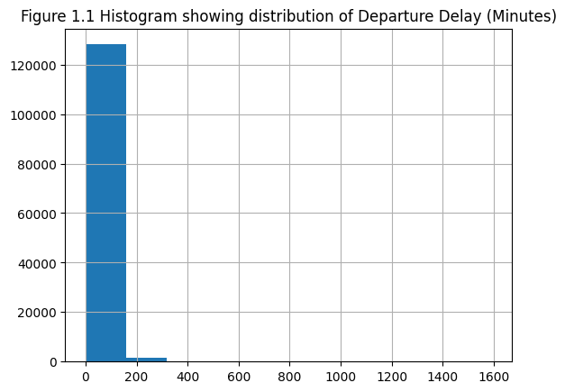

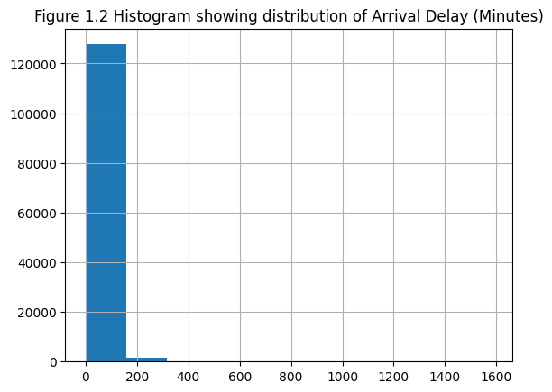

```python
print('\033[1m' + "vii. Plot Distribution of Departure and Arrival Delay using Histogram:\n\n" + '\033[0m')

df.hist(column='Departure Delay')
plt.title('Figure 1.1 Histogram showing distribution of Departure Delay (Minutes)')
plt.show()

df.hist(column='Arrival Delay')
plt.title('Figure 1.2 Histogram showing distribution of Arrival Delay (Minutes)')
plt.show()
```

#### Box and Whisker Plots

```
vii. Plot Distribution of Departure and Arrival Delay using Box and Whisker Plot:
```

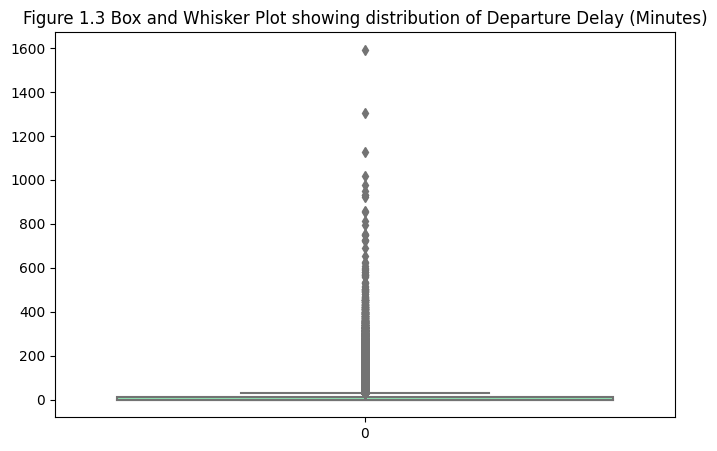

[figure not shown]

```python
print('\033[1m' + "vii. Plot Distribution of Departure and Arrival Delay using Box and Whisker Plot:\n\n" + '\033[0m')

plt.figure(figsize=(8,5))
bw_dep_del = sns.boxplot(df['Departure Delay'], palette='rainbow')
plt.title("Figure 1.3 Box and Whisker Plot showing distribution of Departure Delay (Minutes)")

plt.figure(figsize=(8,5))
bw_arr_del = sns.boxplot(df['Arrival Delay'], palette='rainbow')
plt.title("Figure 1.4 Box and Whisker Plot showing distribution of Departure Delay (Minutes)")
```

## Step 2. Conversion of Numerical Values to Categorical Values

The following columns were discretized to help understand the distribution of these attributes:

- Age
- Flight Distance
- Departure Delay
- Arrival Delay

The details of how the discretization was completed can be seen in the Appendix Section for Step 2.

Most of the customers are Middle Aged, followed by Youths. Senior Citizens and Children make up the least percentage of Customers in the dataset. In terms of advertising, it might be useful to understand these customers’ needs and target middled aged and youth customers. It would also be good to see what influences their overall satisfaction with the airline.

The discretization of Departure Delay and Arrival Delay makes it clearer to see that most of the cases of delays occur for shorter delay times, as discusses in Step 1.

Since Medium haul and Short haul compose of most of the flight trips, it would be good for further analysis to understand how often delays occur for these flights, and what causes those delays. It might also be beneficial to understand the factors that influence overall satisfaction in Short haul trips and Medium haul trips, since they make up most of the flights for this airline.

### Discretization of Age, Flight Distance, and Delays

```python
def descreteAge(age):
  if age >= 0 and age <= 15:
    return "Child"
  elif age >= 16 and age <= 35:
    return "Youth"
  elif age >= 36 and age <= 55:
    return "Middle age"
  elif age >= 56 and age <= 70:
    return "Old"
  elif age > 70:
    return "Senior"
  else:
    return NaN

def discreteFlightDistance(miles):
  if miles >= 0 and miles <= 500:
    return "Short haul"
  elif miles >= 501 and miles <= 3000:
    return "Medium haul"
  elif miles > 3000:
    return "Long haul"
  else:
    return NaN

def discreteDelays(time):
  if time >= 0 and time <= 15:
    return "Small"
  elif time >= 16 and time <= 45:
    return "Medium"
  elif time > 45:
    return "Long"
  else:
    return NaN

df['Age - Nominal'] = df['Age'].apply(descreteAge)
df['Flight Distance - Nominal'] = df['Flight Distance'].apply(discreteFlightDistance)
df['Arrival Delay - Nominal'] = df['Arrival Delay'].apply(discreteDelays)
df['Departure Delay - Nominal'] = df['Departure Delay'].apply(discreteDelays)

print('\033[1m' + "a through c. Discretize Age, Flight Distance and Delays:\n\n" + '\033[0m')

df[['Age', 'Age - Nominal', 'Flight Distance', 'Flight Distance - Nominal', 'Departure Delay', 'Departure Delay - Nominal', 'Arrival Delay', 'Arrival Delay - Nominal']].head(11)
```

```
a through c. Discretize Age, Flight Distance and Delays:
```

|  | Age | Age - Nominal | Flight Distance | Flight Distance - Nominal | Departure Delay | Departure Delay - Nominal | Arrival Delay | Arrival Delay - Nominal |
| --- | --- | --- | --- | --- | --- | --- | --- | --- |
| 0 | 48 | Middle age | 821 | Medium haul | 2 | Small | 5.0 | Small |
| 1 | 35 | Youth | 821 | Medium haul | 26 | Medium | 39.0 | Medium |
| 2 | 41 | Middle age | 853 | Medium haul | 0 | Small | 0.0 | Small |
| 3 | 50 | Middle age | 1905 | Medium haul | 0 | Small | 0.0 | Small |
| 4 | 49 | Middle age | 3470 | Long haul | 0 | Small | 1.0 | Small |
| 5 | 43 | Middle age | 3788 | Long haul | 0 | Small | 0.0 | Small |
| 6 | 43 | Middle age | 1963 | Medium haul | 0 | Small | 0.0 | Small |
| 7 | 60 | Old | 853 | Medium haul | 0 | Small | 3.0 | Small |
| 8 | 50 | Middle age | 2607 | Medium haul | 0 | Small | 0.0 | Small |
| 9 | 38 | Middle age | 2822 | Medium haul | 13 | Small | 0.0 | Small |
| 10 | 28 | Youth | 821 | Medium haul | 0 | Small | 5.0 | Small |

### Distributions of Discretized Values

#### Get Counts for Discretized Columns

```python
df_nom_age = df.groupby(['Age - Nominal'])['Age - Nominal'].count()
df_nom_flight_dist = df.groupby(['Flight Distance - Nominal'])['Flight Distance - Nominal'].count()
df_nom_dep_del = df.groupby(['Departure Delay - Nominal'])['Departure Delay - Nominal'].count()
df_nom_arr_del = df.groupby(['Arrival Delay - Nominal'])['Arrival Delay - Nominal'].count()
```

#### Histogram

```
d. Plot Distribution of Discretized Age, Flight Distance and Delays using Histogram:
```

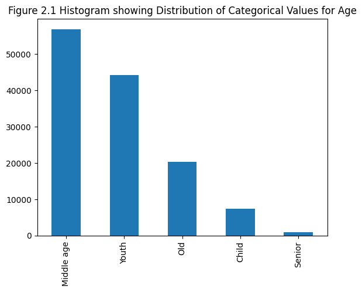

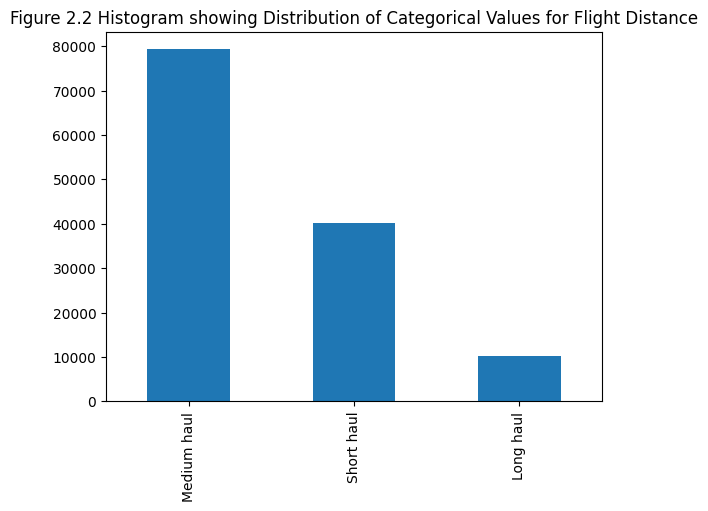

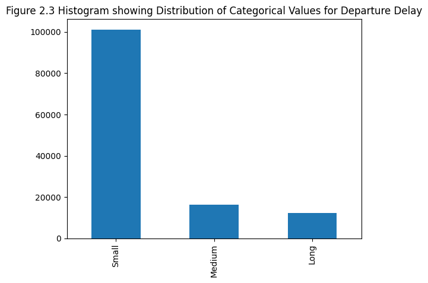

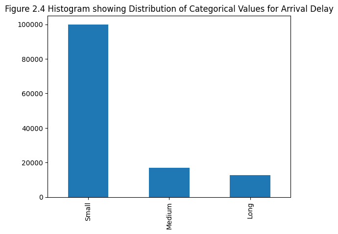

```python
print('\033[1m' + "d. Plot Distribution of Discretized Age, Flight Distance and Delays using Histogram:\n\n" + '\033[0m')

df['Age - Nominal'].value_counts().plot(kind='bar')
plt.title('Figure 2.1 Histogram showing Distribution of Categorical Values for Age')
plt.show()

df['Flight Distance - Nominal'].value_counts().plot(kind='bar')
plt.title('Figure 2.2 Histogram showing Distribution of Categorical Values for Flight Distance')
plt.show()

df['Departure Delay - Nominal'].value_counts().plot(kind='bar')
plt.title('Figure 2.3 Histogram showing Distribution of Categorical Values for Departure Delay')
plt.show()

df['Arrival Delay - Nominal'].value_counts().plot(kind='bar')
plt.title('Figure 2.4 Histogram showing Distribution of Categorical Values for Arrival Delay')
plt.show()
```

#### Box and Whisker Plots

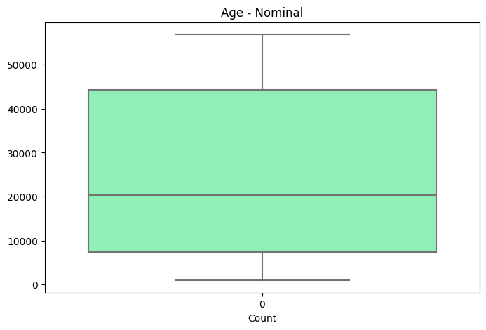

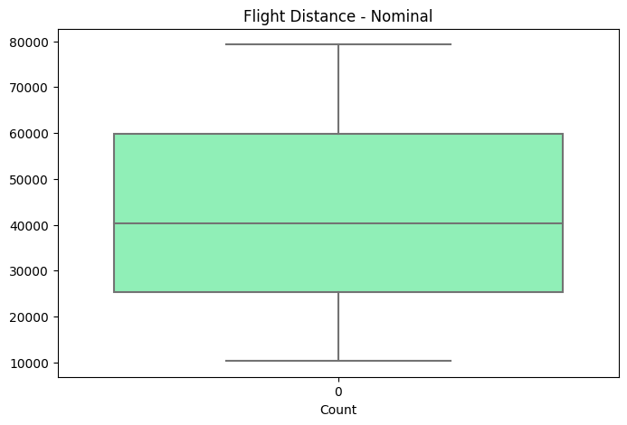

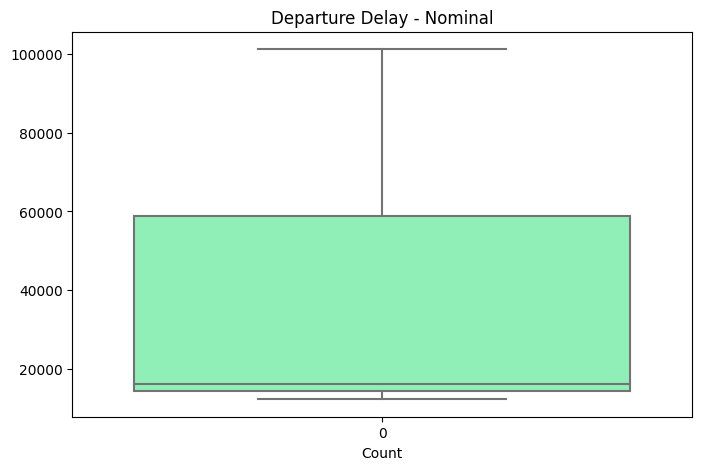

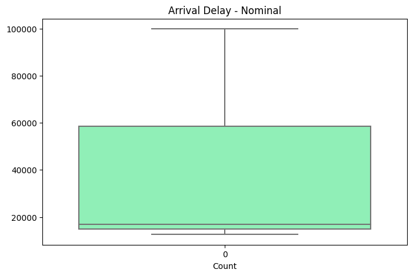

```python
plt.figure(figsize=(8,5))
bw_nom_age = sns.boxplot(df_nom_age, palette='rainbow')
plt.title("Age - Nominal")
plt.xlabel("Count")

plt.figure(figsize=(8,5))
bw_nom_flight_dist = sns.boxplot(df_nom_flight_dist, palette='rainbow')
plt.title("Flight Distance - Nominal")
plt.xlabel("Count")

plt.figure(figsize=(8,5))
bw_nom_dep_del = sns.boxplot(df_nom_dep_del, palette='rainbow')
plt.title("Departure Delay - Nominal")
plt.xlabel("Count")

plt.figure(figsize=(8,5))
bw_nom_arr_del = sns.boxplot(df_nom_arr_del, palette='rainbow')
plt.title("Arrival Delay - Nominal")
plt.xlabel("Count")
```

## Step 3. Test hypotheses

### 3H1: Long haul passengers’ overall satisfaction is influenced more by the in-flight service quality than by the departure delays.

Please refer to Table A3.1. In the table, it can be seen that p values for both In-Flight Service Quality and Departure Delays are both 0, which is below the significance threshold of 0.05. Therefore, both attributes, In-Flight Service Quality and Departure Delays, are related to Overall Satisfaction. Additionally, the correlation coefficient derived from the logistic regression performed is significantly higher for In-Flight Service Quality than Departure Delays. Therefore, there is enough evidence to say that the hypothesis is correct: Long Haul Passengers are more influenced by In-Flight Service Quality than Departure Delays.

This makes sense. Passengers might be initially frustrated by delays, but the quality of service while on the flight can make up for potential delays at the beginning of their journey. The airline service can make note of this and focus on training flight attendants to provide above and beyond service when there are departure delays for longer flights.

```python
# Filter out Long Haul Passengers from the Dataset
longHaulPassengers = df.loc[(df['Flight Distance - Nominal']=='Long haul')]
longHaulPassengers['Satisfaction'] = df['Satisfaction'].replace({'Neutral or Dissatisfied':0, 'Satisfied':1})

# Split Training and Testing Date for Long Haul Passengers
X_train,X_test,y_train,y_test = train_test_split(longHaulPassengers[['In-flight Service', 'Departure Delay']],longHaulPassengers['Satisfaction'], test_size=0.2)

y_train = longHaulPassengers['Satisfaction']
X_train = longHaulPassengers[['In-flight Service', 'Departure Delay']]
log_reg = sm.Logit(np.asarray(y_train), np.asarray(X_train)).fit()
print(log_reg.summary())
```

```
Optimization terminated successfully.
         Current function value: 0.452925
         Iterations 6
                           Logit Regression Results
==============================================================================
Dep. Variable:                      y   No. Observations:                10313
Model:                          Logit   Df Residuals:                    10311
Method:                           MLE   Df Model:                            1
Date:                Mon, 23 Oct 2023   Pseudo R-squ.:                  0.1535
Time:                        10:02:53   Log-Likelihood:                -4671.0
converged:                       True   LL-Null:                       -5517.7
Covariance Type:            nonrobust   LLR p-value:                     0.000
==============================================================================
                 coef    std err          z      P>|z|      [0.025      0.975]
------------------------------------------------------------------------------
x1             0.4390      0.008     57.123      0.000       0.424       0.454
x2            -0.0062      0.001    -10.550      0.000      -0.007      -0.005
==============================================================================
```

```python
# Filter out Long Haul Passengers from the Dataset
medHaulPassengers = df.loc[(df['Flight Distance - Nominal']=='Medium haul')]
medHaulPassengers['Satisfaction'] = df['Satisfaction'].replace({'Neutral or Dissatisfied':0, 'Satisfied':1})
medHaulPassengers = medHaulPassengers.dropna()

# Split Training and Testing Date for Long Haul Passengers
X_train,X_test,y_train,y_test = train_test_split(medHaulPassengers[['In-flight Service', 'Arrival Delay']],medHaulPassengers['Satisfaction'], test_size=0.2)

y_train = medHaulPassengers['Satisfaction']
X_train = medHaulPassengers[['In-flight Service', 'Arrival Delay']]
log_reg2 = sm.Logit(np.asarray(y_train), np.asarray(X_train)).fit()
print(log_reg2.summary())
```

```
Optimization terminated successfully.
         Current function value: 0.688586
         Iterations 5
                           Logit Regression Results
==============================================================================
Dep. Variable:                      y   No. Observations:                79028
Model:                          Logit   Df Residuals:                    79026
Method:                           MLE   Df Model:                            1
Date:                Mon, 23 Oct 2023   Pseudo R-squ.:               -0.003651
Time:                        10:02:53   Log-Likelihood:                -54418.
converged:                       True   LL-Null:                       -54220.
Covariance Type:            nonrobust   LLR p-value:                     1.000
==============================================================================
                 coef    std err          z      P>|z|      [0.025      0.975]
------------------------------------------------------------------------------
x1            -0.0025      0.002     -1.236      0.217      -0.006       0.001
x2            -0.0050      0.000    -22.892      0.000      -0.005      -0.005
==============================================================================
```

### 3H3: Short haul passengers’ overall satisfaction is influenced more by the seat comfort than by the departure delays.

The airline can use this information to spend more money on improving the seat comfort of short flights. If there are occasions when a flight departure is delayed for reasons out of control by the airline, such as weather-related issues, the passengers on these shorter flights will still be satisfied overall by the comfortability of the seats.

```python
# Filter out Long Haul Passengers from the Dataset
shortHaulPassengers = df.loc[(df['Flight Distance - Nominal']=='Short haul')]
shortHaulPassengers['Satisfaction'] = df['Satisfaction'].replace({'Neutral or Dissatisfied':0, 'Satisfied':1})

# Split Training and Testing Date for Long Haul Passengers
X_train,X_test,y_train,y_test = train_test_split(shortHaulPassengers[['Seat Comfort', 'Departure Delay']],shortHaulPassengers['Satisfaction'], test_size=0.2)

y_train = shortHaulPassengers['Satisfaction']
X_train = shortHaulPassengers[['Seat Comfort', 'Departure Delay']]
log_reg = sm.Logit(np.asarray(y_train), np.asarray(X_train)).fit()
print(log_reg.summary())
```

```
Optimization terminated successfully.
         Current function value: 0.661222
         Iterations 5
                           Logit Regression Results
==============================================================================
Dep. Variable:                      y   No. Observations:                40276
Model:                          Logit   Df Residuals:                    40274
Method:                           MLE   Df Model:                            1
Date:                Mon, 23 Oct 2023   Pseudo R-squ.:                -0.03627
Time:                        10:02:53   Log-Likelihood:                -26631.
converged:                       True   LL-Null:                       -25699.
Covariance Type:            nonrobust   LLR p-value:                     1.000
==============================================================================
                 coef    std err          z      P>|z|      [0.025      0.975]
------------------------------------------------------------------------------
x1            -0.0966      0.003    -31.025      0.000      -0.103      -0.090
x2            -0.0090      0.000    -22.504      0.000      -0.010      -0.008
==============================================================================
```

## Step 4. Association Rules

Table A4.2 lists several association rules generated for the following attributes:

These rules can help the airline to understand how passengers use the airline service. For example, from the first rule in the table, it is seen that Senior citizens mostly use the airline to travel for business purposes. From Step 2, it can be seen that Senior citizens make up very little percentage of the customers that use the airline.

If the airline desires to increase the number of senior citizen customers, it might be worthwhile to target advertisement to businesses using the airline service and offer discounts or special promotions. This way, the airline can increase the number of senior citizens using the airline. Additionally, it seems that senior citizens using the airline mostly fly on short or medium haul flights for business purposes. From Step 3, it is known that the overall satisfaction of passengers on medium haul flights are influenced by arrival delays. It is also known that passengers on short haul flights are influenced by seat comfort. In order to keep more senior citizen passengers, it would be beneficial if the airline reduced arrival delays and increased seat comfort. Additional insights like the above can be seen in the link to the full table provided in the Appendix Section A4.

```python
te=TransactionEncoder()

df_part4 = df[['Gender', 'Age - Nominal', 'Type of Travel', 'Flight Distance - Nominal', 'Class', 'Arrival Delay - Nominal']].astype(str).values.tolist()

print('\033[1m' + "df_part4:\n\n" + '\033[0m')
for i in range(10):
  print(df_part4[i])
print()

te_ary=te.fit(df_part4).transform(df_part4)

print('\033[1m' + "te_ary:\n\n" + '\033[0m')
print(te_ary)
print()

df_mod_part4_t =pd.DataFrame(te_ary, columns=te.columns_)

print('\033[1m' + "df_mod_part4_t:\n\n" + '\033[0m')
print(df_mod_part4_t)
print()

frequent_itemsets_airline=apriori(df_mod_part4_t, min_support=(100/len(df_mod_part4_t.index)), use_colnames=True)
frequent_itemsets_airline.to_csv('/content/drive/MyDrive/CS773/Project/fromCoLab/Step4/frequent_itemsets_airline.csv')

print('\033[1m' + "Frequent Itemset:\n\n" + '\033[0m')
print(frequent_itemsets_airline)
print()

rules = association_rules(frequent_itemsets_airline, metric="confidence", min_threshold=0.6)
rules.to_csv('/content/drive/MyDrive/CS773/Project/fromCoLab/Step4/association_rules.csv')

print('\033[1m' + "Association Rules:\n\n" + '\033[0m')
print(rules)
print()
```

[output not shown]

[output cut: 75 more lines]

```

      leverage  conviction  zhangs_metric
0     0.001940    1.013417       0.010857
1     0.000588    1.021479       0.009376
2     0.022542   58.407139       0.309910
3    -0.001940    0.986547      -0.010857
4     0.000724    1.019544       0.008887
...        ...         ...            ...
1537 -0.000002    0.998685      -0.000843
1538 -0.000036    0.955364      -0.014050
1539  0.000103    1.246976       0.056163
1540 -0.000103    0.764638      -0.092379
1541  0.000001    1.002949       0.000883

[1542 rows x 10 columns]
```

## Step 5. Principal Component Analysis

Combining Attributes A10 through A23 using different methods led to the results described by Table 5.1

The best Proxy Variables to use for Overall Satisfaction were Top Three Ranked Combined Attributes using Principal Component Analysis. Using these three Combined Attributes would best serve to stand in for Overall Satisfaction.

\

*Table 5.1 Attributes used as Proxy for Overall Satisfaction sorted in ascending order by R2 Values*

[figure not shown]

\

The explanation for how these results were derived are described in Appendix Section A5.

### Find average, minimum, and maximum of A10-A23 (computed for each passenger record)

```python
df['MINS'] = df[['Departure and Arrival Time Convenience', 'Ease of Online Booking', 'Check-in Service', 'Online Boarding', 'Gate Location', 'On-board Service', 'Seat Comfort', 'Leg Room Service', 'Cleanliness', 'Food and Drink', 'In-flight Service', 'In-flight Wifi Service', 'In-flight Entertainment', 'Baggage Handling']].min(axis=1)
df['MAXS'] = df[['Departure and Arrival Time Convenience', 'Ease of Online Booking', 'Check-in Service', 'Online Boarding', 'Gate Location', 'On-board Service', 'Seat Comfort', 'Leg Room Service', 'Cleanliness', 'Food and Drink', 'In-flight Service', 'In-flight Wifi Service', 'In-flight Entertainment', 'Baggage Handling']].max(axis=1)
df['AVES'] = df[['Departure and Arrival Time Convenience', 'Ease of Online Booking', 'Check-in Service', 'Online Boarding', 'Gate Location', 'On-board Service', 'Seat Comfort', 'Leg Room Service', 'Cleanliness', 'Food and Drink', 'In-flight Service', 'In-flight Wifi Service', 'In-flight Entertainment', 'Baggage Handling']].mean(axis=1)

df_part5 = df.copy()
df_part5['Satisfaction'] = df_part5['Satisfaction'].replace({'Neutral or Dissatisfied':0, 'Satisfied':1})

df_part5
```

|  | ID | Gender | Age | Customer Type | Type of Travel | Class | Flight Distance | Departure Delay | Arrival Delay | Departure and Arrival Time Convenience | ... | In-flight Entertainment | Baggage Handling | Satisfaction | Age - Nominal | Flight Distance - Nominal | Arrival Delay - Nominal | Departure Delay - Nominal | MINS | MAXS | AVES |
| --- | --- | --- | --- | --- | --- | --- | --- | --- | --- | --- | --- | --- | --- | --- | --- | --- | --- | --- | --- | --- | --- |
| 0 | 1 | Male | 48 | First-time | Business | Business | 821 | 2 | 5.0 | 3 | ... | 5 | 5 | 0 | Middle age | Medium haul | Small | Small | 2 | 5 | 3.857143 |
| 1 | 2 | Female | 35 | Returning | Business | Business | 821 | 26 | 39.0 | 2 | ... | 5 | 5 | 1 | Youth | Medium haul | Medium | Medium | 2 | 5 | 3.785714 |
| 2 | 3 | Male | 41 | Returning | Business | Business | 853 | 0 | 0.0 | 4 | ... | 3 | 3 | 1 | Middle age | Medium haul | Small | Small | 3 | 5 | 3.928571 |
| 3 | 4 | Male | 50 | Returning | Business | Business | 1905 | 0 | 0.0 | 2 | ... | 5 | 5 | 1 | Middle age | Medium haul | Small | Small | 2 | 5 | 3.785714 |
| 4 | 5 | Female | 49 | Returning | Business | Business | 3470 | 0 | 1.0 | 3 | ... | 3 | 3 | 1 | Middle age | Long haul | Small | Small | 3 | 5 | 3.500000 |
| ... | ... | ... | ... | ... | ... | ... | ... | ... | ... | ... | ... | ... | ... | ... | ... | ... | ... | ... | ... | ... | ... |
| 129875 | 129876 | Male | 28 | Returning | Personal | Economy Plus | 447 | 2 | 3.0 | 4 | ... | 4 | 4 | 0 | Youth | Short haul | Small | Small | 1 | 5 | 3.785714 |
| 129876 | 129877 | Male | 41 | Returning | Personal | Economy Plus | 308 | 0 | 0.0 | 5 | ... | 2 | 5 | 0 | Middle age | Short haul | Small | Small | 2 | 5 | 3.571429 |
| 129877 | 129878 | Male | 42 | Returning | Personal | Economy Plus | 337 | 6 | 14.0 | 5 | ... | 3 | 5 | 0 | Middle age | Short haul | Small | Small | 1 | 5 | 3.142857 |
| 129878 | 129879 | Male | 50 | Returning | Personal | Economy Plus | 337 | 31 | 22.0 | 4 | ... | 3 | 5 | 1 | Middle age | Short haul | Medium | Medium | 1 | 5 | 3.714286 |
| 129879 | 129880 | Female | 20 | Returning | Personal | Economy Plus | 337 | 0 | 0.0 | 1 | ... | 2 | 1 | 0 | Youth | Short haul | Small | Small | 1 | 4 | 2.500000 |

129880 rows × 31 columns

### Which among PCAS, AVES, MINS, and MAXS could be used as proxy (or proxies) for DA24?

```python
# Split Training and Testing Date for Long Haul Passengers
X_train,X_test,y_train,y_test = train_test_split(df_part5['AVES'],df_part5['Satisfaction'], test_size=0.2)

y_train = df_part5['Satisfaction']
X_train = df_part5['AVES']
log_reg_pcas = sm.Logit(np.asarray(y_train), np.asarray(X_train)).fit()
print(log_reg_pcas.summary())
```

```
Optimization terminated successfully.
         Current function value: 0.692691
         Iterations 3
```

```
                           Logit Regression Results
==============================================================================
Dep. Variable:                      y   No. Observations:               129880
Model:                          Logit   Df Residuals:                   129879
Method:                           MLE   Df Model:                            0
Date:                Mon, 23 Oct 2023   Pseudo R-squ.:                -0.01192
Time:                        10:02:58   Log-Likelihood:                -89967.
converged:                       True   LL-Null:                       -88907.
Covariance Type:            nonrobust   LLR p-value:                       nan
==============================================================================
                 coef    std err          z      P>|z|      [0.025      0.975]
------------------------------------------------------------------------------
x1            -0.0183      0.002    -10.883      0.000      -0.022      -0.015
==============================================================================
```

#### MINS as Proxy

```python
# Split Training and Testing Date for Long Haul Passengers
X_train,X_test,y_train,y_test = train_test_split(df_part5['MINS'],df_part5['Satisfaction'], test_size=0.2)

y_train = df_part5['Satisfaction']
X_train = df_part5['MINS']
log_reg_pcas = sm.Logit(np.asarray(y_train), np.asarray(X_train)).fit()
print(log_reg_pcas.summary())
```

```
Optimization terminated successfully.
         Current function value: 0.693053
         Iterations 3
```

```
                           Logit Regression Results
==============================================================================
Dep. Variable:                      y   No. Observations:               129880
Model:                          Logit   Df Residuals:                   129879
Method:                           MLE   Df Model:                            0
Date:                Mon, 23 Oct 2023   Pseudo R-squ.:                -0.01245
Time:                        10:02:58   Log-Likelihood:                -90014.
converged:                       True   LL-Null:                       -88907.
Covariance Type:            nonrobust   LLR p-value:                       nan
==============================================================================
                 coef    std err          z      P>|z|      [0.025      0.975]
------------------------------------------------------------------------------
x1             0.0164      0.003      4.958      0.000       0.010       0.023
==============================================================================
```

#### MAXS as Proxy

```python
# Split Training and Testing Date for Long Haul Passengers
X_train,X_test,y_train,y_test = train_test_split(df_part5['MAXS'],df_part5['Satisfaction'], test_size=0.2)

y_train = df_part5['Satisfaction']
X_train = df_part5['MAXS']
log_reg_pcas = sm.Logit(np.asarray(y_train), np.asarray(X_train)).fit()
print(log_reg_pcas.summary())
```

```
Optimization terminated successfully.
         Current function value: 0.688297
         Iterations 3
```

```
                           Logit Regression Results
==============================================================================
Dep. Variable:                      y   No. Observations:               129880
Model:                          Logit   Df Residuals:                   129879
Method:                           MLE   Df Model:                            0
Date:                Mon, 23 Oct 2023   Pseudo R-squ.:               -0.005500
Time:                        10:02:58   Log-Likelihood:                -89396.
converged:                       True   LL-Null:                       -88907.
Covariance Type:            nonrobust   LLR p-value:                       nan
==============================================================================
                 coef    std err          z      P>|z|      [0.025      0.975]
------------------------------------------------------------------------------
x1            -0.0414      0.001    -35.405      0.000      -0.044      -0.039
==============================================================================
```

#### AVES as Proxy

```python
# Split Training and Testing Date for Long Haul Passengers
X_train,X_test,y_train,y_test = train_test_split(df_part5['AVES'],df_part5['Satisfaction'], test_size=0.2)

y_train = df_part5['Satisfaction']
X_train = df_part5['AVES']
log_reg_pcas = sm.Logit(np.asarray(y_train), np.asarray(X_train)).fit()
print(log_reg_pcas.summary())
```

```
Optimization terminated successfully.
         Current function value: 0.692691
         Iterations 3
```

```
                           Logit Regression Results
==============================================================================
Dep. Variable:                      y   No. Observations:               129880
Model:                          Logit   Df Residuals:                   129879
Method:                           MLE   Df Model:                            0
Date:                Mon, 23 Oct 2023   Pseudo R-squ.:                -0.01192
Time:                        10:02:59   Log-Likelihood:                -89967.
converged:                       True   LL-Null:                       -88907.
Covariance Type:            nonrobust   LLR p-value:                       nan
==============================================================================
                 coef    std err          z      P>|z|      [0.025      0.975]
------------------------------------------------------------------------------
x1            -0.0183      0.002    -10.883      0.000      -0.022      -0.015
==============================================================================
```

#### 3 PCAs

```python
df_pcas3['Satisfaction'] = df_pcas3['Satisfaction'].replace({'Neutral or Dissatisfied':0, 'Satisfied':1})

# Split Training and Testing Date for Long Haul Passengers
X_train,X_test,y_train,y_test = train_test_split(df_pcas3[['PCAS1','PCAS2','PCAS3']],df_pcas3['Satisfaction'], test_size=0.2)

y_train = df_pcas3['Satisfaction']
X_train = df_pcas3[['PCAS1','PCAS2','PCAS3']]
log_reg_pcas = sm.Logit(np.asarray(y_train), np.asarray(X_train)).fit()
print(log_reg_pcas.summary())
```

```
Optimization terminated successfully.
         Current function value: 0.537959
         Iterations 6
```

```
                           Logit Regression Results
==============================================================================
Dep. Variable:                      y   No. Observations:               129880
Model:                          Logit   Df Residuals:                   129877
Method:                           MLE   Df Model:                            2
Date:                Mon, 23 Oct 2023   Pseudo R-squ.:                  0.2141
Time:                        10:02:59   Log-Likelihood:                -69870.
converged:                       True   LL-Null:                       -88907.
Covariance Type:            nonrobust   LLR p-value:                     0.000
==============================================================================
                 coef    std err          z      P>|z|      [0.025      0.975]
------------------------------------------------------------------------------
x1            -0.6952      0.004   -166.719      0.000      -0.703      -0.687
x2             0.0036      0.004      0.871      0.384      -0.005       0.012
x3             0.0630      0.004     14.269      0.000       0.054       0.072
==============================================================================
```

## Step 6. Linear Regresssion

### Flight Distance (in miles) vs. Arrival Delay (in minutes)

The scatter plot in Figure 6.1 shows the relationship between Flight Distance and Arrival Delay.

From both Figure 6.1, and the r-squared value of 0 for this Linear Regression, it is obvious from the plot that no significant linear relationship exists between Flight Distance and Arrival Delay. Therefore, the airline can rule out the possibility that Arrival Delay has any linear dependency on the Flight Distance.

```
Correlation between Flight Distance (Miles) and Arrival Delay (Minutes):
                 Flight Distance  Arrival Delay
Flight Distance         1.000000      -0.001935
Arrival Delay          -0.001935       1.000000
```

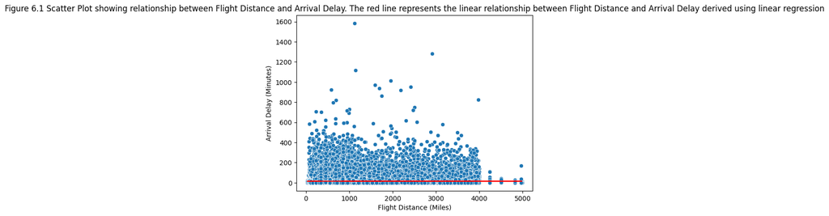

```
                            OLS Regression Results
==============================================================================
Dep. Variable:          Arrival Delay   R-squared:                       0.000
Model:                            OLS   Adj. R-squared:                 -0.000
Method:                 Least Squares   F-statistic:                 0.0009733
Date:                Mon, 23 Oct 2023   Prob (F-statistic):              0.975
Time:                        10:03:00   Log-Likelihood:            -3.9326e+05
No. Observations:               77692   AIC:                         7.865e+05
Df Residuals:                   77690   BIC:                         7.865e+05
Df Model:                           1
Covariance Type:            nonrobust
===================================================================================
                      coef    std err          t      P>|t|      [0.025      0.975]
-----------------------------------------------------------------------------------
const              15.0085      0.214     70.295      0.000      14.590      15.427
Flight Distance  4.285e-06      0.000      0.031      0.975      -0.000       0.000
==============================================================================
Omnibus:                    95472.031   Durbin-Watson:                   2.012
Prob(Omnibus):                  0.000   Jarque-Bera (JB):         23626548.020
Skew:                           6.491   Prob(JB):                         0.00
Kurtosis:                      87.439   Cond. No.                     2.42e+03
==============================================================================

Notes:
[1] Standard Errors assume that the covariance matrix of the errors is correctly specified.
[2] The condition number is large, 2.42e+03. This might indicate that there are
strong multicollinearity or other numerical problems.
-2.5980538993941593e-05
```

```python
# Show Scatter Plot
fig_scatt_i = sns.scatterplot(data=df,x='Flight Distance',y='Arrival Delay')
plt.title("Figure 6.1 Scatter Plot showing relationship between Flight Distance and Arrival Delay. The red line represents the linear relationship between Flight Distance and Arrival Delay derived using linear regression")
plt.xlabel("Flight Distance (Miles)")
plt.ylabel("Arrival Delay (Minutes)")
print()

# Show Correlation
print('\033[1m' + "Correlation between Flight Distance (Miles) and Arrival Delay (Minutes):" + '\033[0m')
print(df[['Flight Distance', 'Arrival Delay']].corr())
print()

# Linear Regression
df = df.dropna()
X_train, X_test, y_train, y_test = train_test_split(df['Flight Distance'], df['Arrival Delay'], test_size=0.4, random_state=101)
model = LinearRegression()
model.fit(X_train.values.reshape(-1,1),y_train.values.reshape(-1,1))

# print the Linear Regression Equation on top of the Scatter Plot
plt.plot(df['Flight Distance'], model.coef_[0][0]*df['Flight Distance']+model.intercept_[0], color='red')
plt.show()

# Find R-squared Value
X_train_Sm= sm.add_constant(X_train)
ls=sm.OLS(y_train,X_train_Sm).fit()
print(ls.summary())

# Predict and get accuracy
score = model.score(X_test.values.reshape(-1,1), y_test.values.reshape(-1,1))
print(score)
```

### Flight distance (in miles) and departure delay (in minutes)

The scatter plot in Figure 6.2 shows the relationship between Flight Distance and Departure Delay.

Again, from both Figure 6.2 and the r-squared value of 0 for this Linear Regression, it is obvious that no significant linear relationship exists between Flight Distance and Departure Delay. Therefore, from both Figures 6.1 and 6.2, the airline can rule out the possibility that Delays have any linear dependency on the Flight Distance.

```
Correlation between Flight Distance (Miles) and Departure Delay (Minutes):
                 Flight Distance  Departure Delay
Flight Distance         1.000000         0.001992
Departure Delay         0.001992         1.000000
```

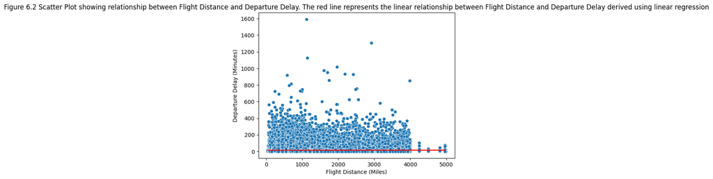

```
                            OLS Regression Results
==============================================================================
Dep. Variable:        Departure Delay   R-squared:                       0.000
Model:                            OLS   Adj. R-squared:                 -0.000
Method:                 Least Squares   F-statistic:                    0.5347
Date:                Mon, 23 Oct 2023   Prob (F-statistic):              0.465
Time:                        10:03:00   Log-Likelihood:            -3.9226e+05
No. Observations:               77692   AIC:                         7.845e+05
Df Residuals:                   77690   BIC:                         7.845e+05
Df Model:                           1
Covariance Type:            nonrobust
===================================================================================
                      coef    std err          t      P>|t|      [0.025      0.975]
-----------------------------------------------------------------------------------
const              14.4377      0.211     68.501      0.000      14.025      14.851
Flight Distance  9.915e-05      0.000      0.731      0.465      -0.000       0.000
==============================================================================
Omnibus:                    97520.943   Durbin-Watson:                   2.013
Prob(Omnibus):                  0.000   Jarque-Bera (JB):         27673964.817
Skew:                           6.705   Prob(JB):                         0.00
Kurtosis:                      94.482   Cond. No.                     2.42e+03
==============================================================================

Notes:
[1] Standard Errors assume that the covariance matrix of the errors is correctly specified.
[2] The condition number is large, 2.42e+03. This might indicate that there are
strong multicollinearity or other numerical problems.
```

```python
# Show Scatter Plot
fig_scatt_i = sns.scatterplot(data=df,x='Flight Distance',y='Departure Delay')
plt.title("Figure 6.2 Scatter Plot showing relationship between Flight Distance and Departure Delay. The red line represents the linear relationship between Flight Distance and Departure Delay derived using linear regression")
plt.xlabel("Flight Distance (Miles)")
plt.ylabel("Departure Delay (Minutes)")
print()

# Show Correlation
print('\033[1m' + "Correlation between Flight Distance (Miles) and Departure Delay (Minutes):" + '\033[0m')
print(df[['Flight Distance', 'Departure Delay']].corr())
print()

# Linear Regression
X_train, X_test, y_train, y_test = train_test_split(df['Flight Distance'], df['Departure Delay'], test_size=0.4, random_state=101)
model = LinearRegression()
model.fit(X_train.values.reshape(-1,1),y_train.values.reshape(-1,1))

# print the Linear Regression Equation on top of the Scatter Plot
plt.plot(df['Flight Distance'], model.coef_[0][0]*df['Flight Distance']+model.intercept_[0], color='red')
plt.show()

# Find R-squared Value
X_train_Sm= sm.add_constant(X_train)
ls=sm.OLS(y_train,X_train_Sm).fit()
print(ls.summary())
```

## Step 7. Data Mining to Understand Attribute Relationships Part 1

For details on how these relationships were evaluated, please refer to Appendix Section A7.

### Step 7a. Is satisfaction with seat comfort related (or depends on) to passenger Gender?

Seat Comfort is dependent on Passenger Gender. Please refer to Figure 7.1. Males appeared to be slightly more dissatisfied than females with Seat Comfort on this airline.

This could be because males are typically larger and need more space on the flight to stretch out and sit comfortably.

```
seatComfort_contingency:
Seat Comfort  0     1     2      3      4      5
Gender
Female        1  7072  8838  12103  20745  16944
Male          0  7987  9624  11155  18906  16112


chi2_stat:  206.53896582538988
pvalue:  1.13304715395621e-42
dof:  5
exp:
 [[5.07410010e-01 7.64108734e+03 9.36780361e+03 1.18013420e+04
  2.01193143e+04 1.67729453e+04]
 [4.92589990e-01 7.41791266e+03 9.09419639e+03 1.14566580e+04
  1.95316857e+04 1.62830547e+04]]
```

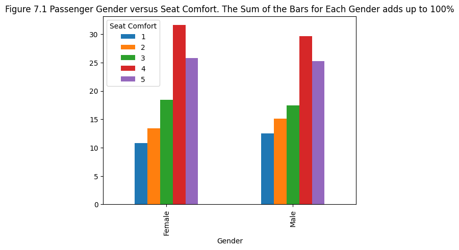

```python
# https://towardsdatascience.com/an-interactive-guide-to-hypothesis-testing-in-python-979f4d62d85

# 7a. Null - Satisfaction with Seat comfort and Gender are independent to each other
# 7a. Alternate - Satisfaction with Seat comfort and Gender are dependent to each other
#     Use chi squared test

seatComfort_contingency = pd.crosstab(df['Gender'], df['Seat Comfort'])
print("seatComfort_contingency:")
print(seatComfort_contingency, "\n\n")

# seatComfort_contingency.plot(kind='bar', stacked=True)

chi2_stat, pvalue, dof, exp = chi2_contingency(seatComfort_contingency)
print("chi2_stat: ", chi2_stat)
print("pvalue: ", pvalue)
print("dof: ", dof)
print("exp:\n", exp)
print("\n\n\n")

# Normalize Data to make viewing of bar plot easier

seatComfort_contingency = seatComfort_contingency.iloc[: , 1:]
#print(seatComfort_contingency.div(seatComfort_contingency.sum(axis=1), axis=0))
seatComfort_contingency_norm = seatComfort_contingency.div(seatComfort_contingency.sum(axis=1), axis=0)*100

ax = seatComfort_contingency_norm.plot(kind='bar', stacked=False)
plt.title('Figure 7.1 Passenger Gender versus Seat Comfort. The Sum of the Bars for Each Gender adds up to 100%')
# ax.set_ylim([0, 100])
```

### Step 7b. Is satisfaction with gate location related to passenger age?

```
gateLocation_contingency:
Gate Location  0      1      2      3      4     5
Age - Nominal
Child          0   1099   1309   2495   1918   615
Middle age     1  10081  10850  14320  12636  8817
Old            0   3504   3891   5578   4631  2640
Senior         0    176    180    225    213   169
Youth          0   7066   7989  12993  10978  5113


chi2_stat:  917.9852885655065
pvalue:  1.1670701136360427e-181
dof:  20
exp:
 [[5.74266143e-02 1.25913594e+03 1.39081517e+03 2.04501916e+03
  1.74439083e+03 9.96581464e+02]
 [3.40875918e-01 7.47404538e+03 8.25567386e+03 1.21389323e+04
  1.03544469e+04 5.91556068e+03]
 [4.37920409e-01 9.60184289e+03 1.06059944e+04 1.55947837e+04
  1.33022703e+04 7.59967078e+03]
 [1.56340019e-01 3.42791125e+03 3.78639891e+03 5.56742441e+03
  4.74898441e+03 2.71312468e+03]
 [7.43704001e-03 1.63064539e+02 1.80117672e+02 2.64840432e+02
  2.25907527e+02 1.29062392e+02]]
```

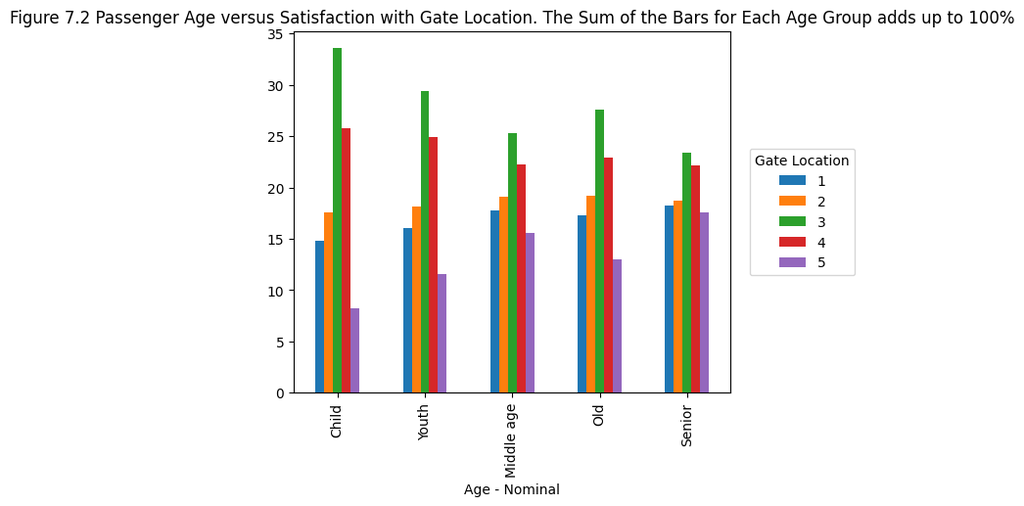

```python
# 7b. Alternate - Satisfaction with Gate Location and Age (Nominal) are dependent to each other
#     Use chi squared test
# 7b. Null - Satisfaction with Gate Location and Age (Nominal) are independent to each other

gateLocation_contingency = pd.crosstab(df['Age - Nominal'], df['Gate Location'])
print("gateLocation_contingency:")
print(gateLocation_contingency, "\n\n")
gateLocation_contingency = gateLocation_contingency.reindex(['Child', 'Youth', 'Middle age', 'Old', 'Senior'])
chi2_stat, pvalue, dof, exp = chi2_contingency(gateLocation_contingency)
print("chi2_stat: ", chi2_stat)
print("pvalue: ", pvalue)
print("dof: ", dof)
print("exp:\n", exp)
print("\n\n\n")


# Normalize Data to make viewing of bar plot easier

gateLocation_contingency = gateLocation_contingency.iloc[: , 1:]
# print(gateLocation_contingency.div(gateLocation_contingency.sum(axis=1), axis=0))
gateLocation_contingency_norm = gateLocation_contingency.div(gateLocation_contingency.sum(axis=1), axis=0)*100

ax = gateLocation_contingency_norm.plot(kind='bar', stacked=False)
pos = ax.get_position()
ax.set_position([pos.x0, pos.y0, pos.width * 0.9, pos.height])
ax.legend(loc='center right', bbox_to_anchor=(1.3, 0.5), title="Gate Location")
plt.title("Figure 7.2 Passenger Age versus Satisfaction with Gate Location. The Sum of the Bars for Each Age Group adds up to 100%")
# ax.set_ylim([0, 100])
```

### Step 7c. Do first time passengers have more or less expectations than returning customers measured in terms of overall satisfaction?

There is a relationship between Customer Type and Overall Satisfaction. Please refer to Figure 7.3. Although, there are less First-time customers than Returning customers, it is clear from the chart that First-time customers are less satisfied with the airline overall, than returning customers.

```
contingency_7c:
Satisfaction   Neutral or Dissatisfied  Satisfied
Customer Type
First-time                       18026       5688
Returning                        55199      50574


chi2_stat:  4475.155050825033
pvalue:  0.0
dof:  1
exp:
 [[13410.28558851 10303.71441149]
 [59814.71441149 45958.28558851]]
```

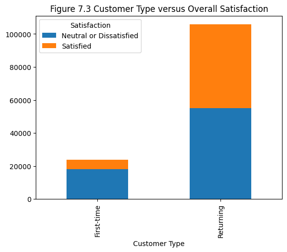

```python
contingency_7c = pd.crosstab(df['Customer Type'], df['Satisfaction'])
print("contingency_7c:")
print(contingency_7c, "\n\n")

contingency_7c.plot(kind='bar', stacked=True)
plt.title("Figure 7.3 Customer Type versus Overall Satisfaction")

chi2_stat, pvalue, dof, exp = chi2_contingency(contingency_7c)
print("chi2_stat: ", chi2_stat)
print("pvalue: ", pvalue)
print("dof: ", dof)
print("exp:\n", exp)
print("\n\n\n")
```

### Step 7d. Is there a distinct (statistically significant) difference between business and personal travelers (A5) in terms of their reaction to their flights?

There is a difference between business and personal travelers in terms of Overall Satisfaction. As can be seen from Figure 7.4, Personal Travelers are clearly more dissatisfied with the airline.

```
contingency_7d:
Satisfaction    Neutral or Dissatisfied  Satisfied
Type of Travel
Business                          37238      52207
Personal                          35987       4055


chi2_stat:  26195.13977467199
pvalue:  0.0
dof:  1
exp:
 [[50581.21761258 38863.78238742]
 [22643.78238742 17398.21761258]]
```

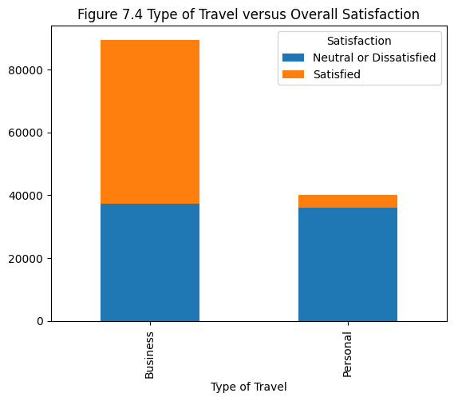

```python
contingency_7d = pd.crosstab(df['Type of Travel'], df['Satisfaction'])
print("contingency_7d:")
print(contingency_7d, "\n\n")

contingency_7d.plot(kind='bar', stacked=True)
plt.title("Figure 7.4 Type of Travel versus Overall Satisfaction")

chi2_stat, pvalue, dof, exp = chi2_contingency(contingency_7d)
print("chi2_stat: ", chi2_stat)
print("pvalue: ", pvalue)
print("dof: ", dof)
print("exp:\n", exp)
print("\n\n\n")
```

### Step 7e. Is there a distinct (statistically significant) difference between business class passengers and economy passengers (A6) in terms of their reaction to satisfaction with food-and-drink?

Yes, there is a difference between business class passengers and economy passengers in terms of their Satisfaction with Food and Drink. Referring to Figure 7.5, Economy Passengers appear to be slightly more dissatisfied with their Food and Drink than Business Passengers.

```
contingency_7e:
Food and Drink   0     1      2      3      4      5
Class
Business        37  5360  13186  13407  15539  14461
Economy         72  9230  12151  12328  12822  11514


chi2_stat:  1596.6886839358283
pvalue:  0.0
dof:  5
exp:
 [[   56.25742047  7530.23637257 13077.01158134 13282.42858451
  14637.76790695 13406.29813416]
 [   52.74257953  7059.76362743 12259.98841866 12452.57141549
  13723.23209305 12568.70186584]]
```

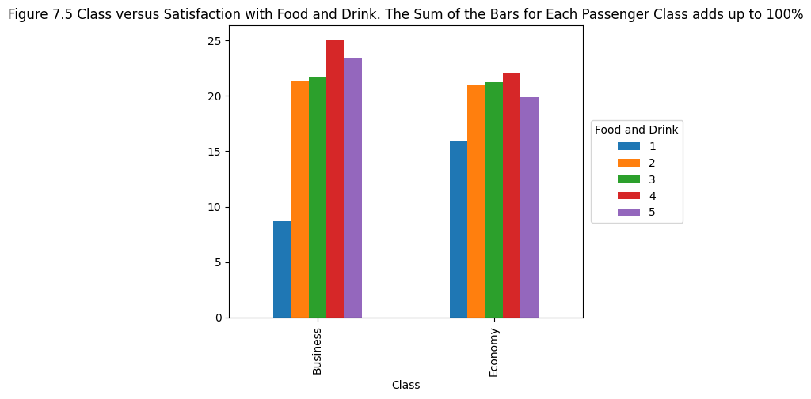

```python
contingency_7e = pd.crosstab(df.loc[(df['Class']=='Business') | (df['Class']=='Economy')]['Class'], df['Food and Drink'])
print("contingency_7e:")
print(contingency_7e, "\n\n")

# contingency_7e.plot(kind='bar', stacked=True)

chi2_stat, pvalue, dof, exp = chi2_contingency(contingency_7e)
print("chi2_stat: ", chi2_stat)
print("pvalue: ", pvalue)
print("dof: ", dof)
print("exp:\n", exp)
print("\n\n\n")

# Normalize Data to make viewing of bar plot easier

contingency_7e = contingency_7e.iloc[: , 1:]
# print(contingency_7e.div(contingency_7e.sum(axis=1), axis=0))
contingency_7e_norm = contingency_7e.div(contingency_7e.sum(axis=1), axis=0)*100

ax = contingency_7e_norm.plot(kind='bar', stacked=False)
pos = ax.get_position()
ax.set_position([pos.x0, pos.y0, pos.width * 0.9, pos.height])
ax.legend(loc='center right', bbox_to_anchor=(1.3, 0.5), title="Food and Drink")
plt.title("Figure 7.5 Class versus Satisfaction with Food and Drink. The Sum of the Bars for Each Passenger Class adds up to 100%")
# ax.set_ylim([0, 100])
```

## Step 8. Data Mining to Understand Attribute Relationships Part 2

### Relationship between Check-In Service and Baggage Handling

If there was no relationship between Check-In Service and Baggage Handling, then the values for Baggage Handling would not vary at all when Check-In Service Satisfaction varies.

```
checkIn_contingency:
Baggage Handling     1     2     3      4      5
Check-in Service
0                    0     0     1      0      0
1                 1689  2703  5080   4819   1767
2                 1600  2724  5106   4737   1889
3                 2230  3575  6452  13168   9918
4                 2188  3578  6486  13628  10349
5                 1301  1736  2646  10279   9838


chi2_stat:  10523.394282177645
pvalue:  0.0
dof:  20
exp:
 [[6.95668291e-02 1.10559361e-01 1.99023840e-01 3.60121093e-01
  2.60728876e-01]
 [1.11710414e+03 1.77536222e+03 3.19592483e+03 5.78282452e+03
  4.18678429e+03]
 [1.11696501e+03 1.77514110e+03 3.19552678e+03 5.78210427e+03
  4.18626284e+03]
 [2.45870044e+03 3.90749950e+03 7.03409959e+03 1.27277598e+04
  9.21494067e+03]
 [2.52033665e+03 4.00545510e+03 7.21043471e+03 1.30468271e+04
  9.44594646e+03]
 [1.79482419e+03 2.85243152e+03 5.13481508e+03 9.29112421e+03
  6.72680501e+03]]




Baggage Handling         1         2         3         4         5
Check-in Service
1                 0.105181  0.168327  0.316353  0.300100  0.110039
2                 0.099651  0.169656  0.318012  0.295030  0.117651
3                 0.063096  0.101152  0.182554  0.372577  0.280621
4                 0.060394  0.098761  0.179028  0.376163  0.285655
5                 0.050426  0.067287  0.102558  0.398411  0.381318
```

[figure not shown]

```python
# 8a. Null - Satisfaction with Check in service and Baggage handling are independent to each other
# 8a. Alternate - Satisfaction with Check in service and Baggage handling are dependent to each other
#     Use chi squared test

checkIn_contingency = pd.crosstab(df['Check-in Service'], df['Baggage Handling'])
print("checkIn_contingency:")
print(checkIn_contingency, "\n\n")

chi2_stat, pvalue, dof, exp = chi2_contingency(checkIn_contingency)
print("chi2_stat: ", chi2_stat)
print("pvalue: ", pvalue)
print("dof: ", dof)
print("exp:\n", exp)
print("\n\n\n")


# # Normalize Data to make viewing of bar plot easier
# normalize_min = 0.1
# normalize_max = 1
# checkIn_contingency[checkIn_contingency.columns]= preprocessing.minmax_scale(checkIn_contingency[checkIn_contingency.columns], feature_range=(normalize_min, normalize_max))

# checkIn_contingency.plot(kind='bar', stacked=False)
# plt.title('Check-in Service and Baggage Handling')

# Normalize Data to make viewing of bar plot easier

checkIn_contingency = checkIn_contingency.iloc[1: , :]
print(checkIn_contingency.div(checkIn_contingency.sum(axis=1), axis=0))
checkIn_contingency_norm = checkIn_contingency.div(checkIn_contingency.sum(axis=1), axis=0)*100

ax = checkIn_contingency_norm.plot(kind='bar', stacked=False)
pos = ax.get_position()
ax.set_position([pos.x0, pos.y0, pos.width * 0.9, pos.height])
ax.legend(loc='center right', bbox_to_anchor=(1.5, 0.5), title="Baggage Handling")
plt.title("Figure 8.1 Stacked Bar Chart showing relationship between Check-in Service and Baggage Handling. The Sum of the Bars for Each Check-in Service Rating adds up to 100%")

# ax.set_ylim([0, 100])
```

### Departure and Arrival Time Convenience versus Seat Comfort Effect on Overall Satisfaction

Please refer to Table A8.1.

In the table, it can be seen that the p values for both Departure and Arrival Time Convenience and Seat Comfort are both 0, which is below the significance threshold of 0.05. Therefore, both attributes, Departure and Arrival Time Convenience and Seat Comfort, are related to Overall Satisfaction. However, the correlation coefficient for Departure and Arrival Time Convenience is slightly higher than the correlation coefficient for Seat Comfort. Therefore, the airline should know that Departure and Arrival Time Convenience has more of an effect on Overall Satisfaction than Seat Comfort for all passengers.

The airline should make some efforts in understanding what impacts Departure and Arrival Time Convenience in order to improve customer satisfaction in this area.

```python
df_step8_b = df.copy()
df_step8_b['Satisfaction'] = df_step8_b['Satisfaction'].replace({'Neutral or Dissatisfied':0, 'Satisfied':1})


# Split Training and Testing Date for Long Haul Passengers
X_train,X_test,y_train,y_test = train_test_split(df_step8_b[['Departure and Arrival Time Convenience', 'Seat Comfort']],df_step8_b['Satisfaction'], test_size=0.2)

y_train = df_step8_b['Satisfaction']
X_train = df_step8_b[['Departure and Arrival Time Convenience', 'Seat Comfort']]
log_reg = sm.Logit(np.asarray(y_train), np.asarray(X_train)).fit()
print(log_reg.summary())
```

```
Optimization terminated successfully.
         Current function value: 0.658341
         Iterations 4
                           Logit Regression Results
==============================================================================
Dep. Variable:                      y   No. Observations:               129487
Model:                          Logit   Df Residuals:                   129485
Method:                           MLE   Df Model:                            1
Date:                Thu, 23 Jun 2022   Pseudo R-squ.:                 0.03827
Time:                        09:27:29   Log-Likelihood:                -85247.
converged:                       True   LL-Null:                       -88639.
Covariance Type:            nonrobust   LLR p-value:                     0.000
==============================================================================
                 coef    std err          z      P>|z|      [0.025      0.975]
------------------------------------------------------------------------------
x1            -0.2943      0.003    -91.058      0.000      -0.301      -0.288
x2             0.2294      0.003     77.555      0.000       0.224       0.235
==============================================================================
```

# Appendix

With the exception of Step 5 (PCA), the majority of the Steps were run using Python.

The csv file containing the airline satisfaction data was loaded into a Pandas Library DataFrame object. The DataFrame object was used and manipulated to help provide insights and analysis for this report.

More information on the Pandas Library and the DataFrame object can be found here: https://pandas.pydata.org/docs/reference/frame.html

The Seaborn Library was used for many of the visualizations. More information on the Seaborn library can be found here: https://seaborn.pydata.org/api.html

The “statsmodel” Python Library provides a function to perform both linear and logistic regression on different attributes and the binary output variable. More information on the library can be found here: https://www.statsmodels.org/stable/api.html

The “mlxtend” library in Python has built in tools to generate frequent item sets and association rules for a dataset. More information on how to use this library can be found here: http://rasbt.github.io/mlxtend/user_guide/frequent_patterns/association_rules/

The “scipy.stats” library was used to calculate chi squared values for determining the relationships between categorical attributes. More information on the library can be found here: https://docs.scipy.org/doc/scipy/reference/stats.html

## A1. Statistics on Departure Delay and Arrival Delay

Python has many built in functions to calculate statistics using a data frame object. Below are the DataFrame functions that were used to calculate the relevant statistics for the Departure Delay and Arrival Delay columns in the DataFrame:

- mean()
- mode()
- median()
- std()
- quantile(q)
  - Takes in a parameter, q, which is a float or decimal value between 0 and 1 indicating which quantile to compute for the DataFrame
- skew()
- cov()
  - Calculates Pairwise Covariance between two columns of the DataFrame
- corr()
  - Calculates Pairwise Correlation between two columns of the DataFrame
- hist()
  - Can specify columns of the DataFrame for which to display histogram The DataFrame column must be a numerical variable

Additionally, the Seaborn Library in Python also provides useful functions to help visualize distributions.

The following function from the Seaborn library was used to display a Box and Whisker Plot for the Departure and Arrival Delay columns of the DataFrame.

- boxplot()

## A2. Conversion of Numerical Values to Categorical Values

The following discretization was applied:

- Age:
  - 0-15 🡪 Child
  - 16-35 🡪 Youth
  - 36-55 🡪 Middle age
  - 56-70 🡪 Old
  - >70 🡪 Senior
- Flight distance:
  - 0-500 miles 🡪 Short haul
  - 501-3000 miles 🡪 Medium haul
  - >3000 🡪 Long haul
- Departure and Arrival Delays:
  - 0-15 🡪 Small
  - 16-45 🡪 Medium
  - >45 🡪 Long

The histograms were created using the “plot” function from the Pandas DataFrame Library. Since the attributes were now discretized and no longer numerical values, the histograms were actually created using a bar plot, instead of the “hist” plot function available in the Pandas DataFrame Library.

## A3. Test hypotheses

All three hypotheses are looking at the relationship between different attributes to Overall Satisfaction. Overall Satisfaction is a binary variable, as there are only two possible values: “Neutral or Dissatisfied” or “Satisfied”. Since we are looking at the relationship with a binary output variable, the best method to test hypotheses would be to use logistic regression.

Using Logistic Regression provides us with the following values:

For all three hypotheses, the significance threshold of 0.05 was used.

If the p-value was less than the significance threshold of 0.05, then it was determined that there was a relationship between the attribute and the output variable.

The correlation coefficient indicated the strength of the relationship between the attribute and the output variable.

Tables A3.1 through A3.3 summarize the correlation coefficient, z-statistics, and p-values for all three hypotheses. To see the code and runs for the logistic regression for all three hypotheses in Python, please refer to the Section, “Step 3. Test hypotheses”, in the Colab link provided at the top of the Appendix.

\ *Table A3.1 Correlation Coefficient, z-statistic, and p-value for Hypothesis 3H1*

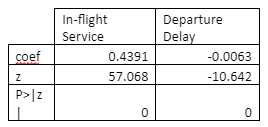

\

*Table A3.2 Correlation Coefficient, z-statistic, and p-value for Hypothesis 3H2*

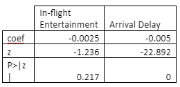

\

*Table A3.3 Correlation Coefficient, z-statistic, and p-value for Hypothesis 3H3*

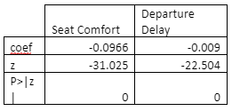

A3. Test hypotheses

All three hypotheses are looking at the relationship between different attributes to Overall Satisfaction. Overall Satisfaction is a binary variable, as there are only two possible values: “Neutral or Dissatisfied” or “Satisfied”. Since we are looking at the relationship with a binary output variable, the best method to test hypotheses would be to use logistic regression.

Using Logistic Regression provides us with the following values:

- Correlation coefficient for each attribute
- Z-statistic for each attribute
- P-value for each attribute

For all three hypotheses, the significance threshold of 0.05 was used.

If the p-value was less than the significance threshold of 0.05, then it was determined that there was a relationship between the attribute and the output variable.

The correlation coefficient indicated the strength of the relationship between the attribute and the output variable.

Tables A3.1 through A3.3 summarize the correlation coefficient, z-statistics, and p-values for all three hypotheses. To see the code and runs for the logistic regression for all three hypotheses in Python, please refer to the Section, “Step 3. Test hypotheses”, in the Colab link provided at the top of the Appendix.

\ *Table A3.1 Correlation Coefficient, z-statistic, and p-value for Hypothesis 3H1*

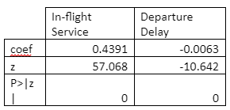

\ *Table A3.2 Correlation Coefficient, z-statistic, and p-value for Hypothesis 3H2*

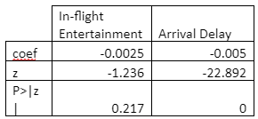

*Table A3.3 Correlation Coefficient, z-statistic, and p-value for Hypothesis 3H3*

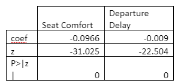

## A4. Association Rules

Table A4.1 and Table A4.2 were generated using the tools in the “mlxtend” library. Both Tables only display the first 25 rows. To see the full tables generated by the code, please refer to this folder here:

https://drive.google.com/drive/folders/1-BerWdQTHvjktPYzX_o7tlYOBfmiW_NN?usp=sharing To see the code and runs for the frequent item set and association rule generation in Python, please refer to the Section, “Step 4. Association Rules”, in the Colab link provided at the top of the Appendix.

\

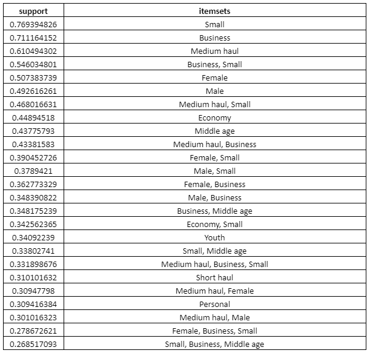

\

*Table A4.2 Association Rules generated based on the Frequent Itemsets in Table A4.1. The minimum confidence used was 60%. Rules are sorted in descending order by the confidence value.*

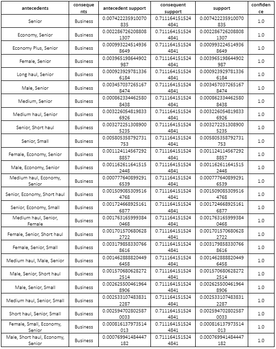

## A5. Principal Component Analysis

The Principal Component Analysis was completed using Weka.

After the first nine attributes were removed, the unsupervised Principal Components Filter was applied for attributes A10 through A23. Figure 1 shows the Best Ranked Attribute after combining attributes A10 through A23.

*Figure A5.1 Best Ranked Combined Attribute (Attributes A10 through A23) using Principal Component Analysis in Weka, along with Satisfaction Class*

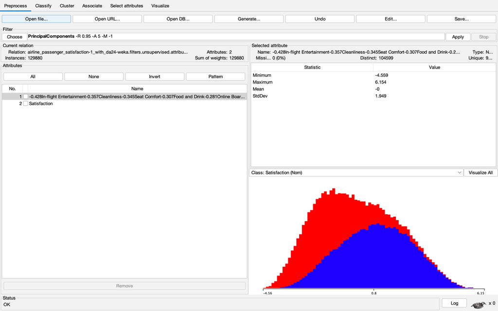

\

After getting the top ranked combined attribute in Weka, the file was saved and converted into a csv file. This csv file was loaded into a Pandas DataFrame object in Python. Then, logistic regression was performed in order to get the R2 value for using the Best Ranked Combined Attributes as a proxy variable for Satisfaction.

Similarly, Weka was used to compute the best three ranked combined components using Principal Component Analysis, as seen in Figure A5.2.

Again, the saved filed with the best three ranked combined components was loaded into a Pandas DataFrame object in Python. Then, again logistic regression was performed in order to get the R2 value for using the Best Three Ranked Combined Attributes as a proxy variable for Satisfaction.

\

*Figure A5.2 Best Three Ranked Combined Attribute (Attributes A10 through A23) using Principal Component Analysis in Weka, along with Satisfaction Class*

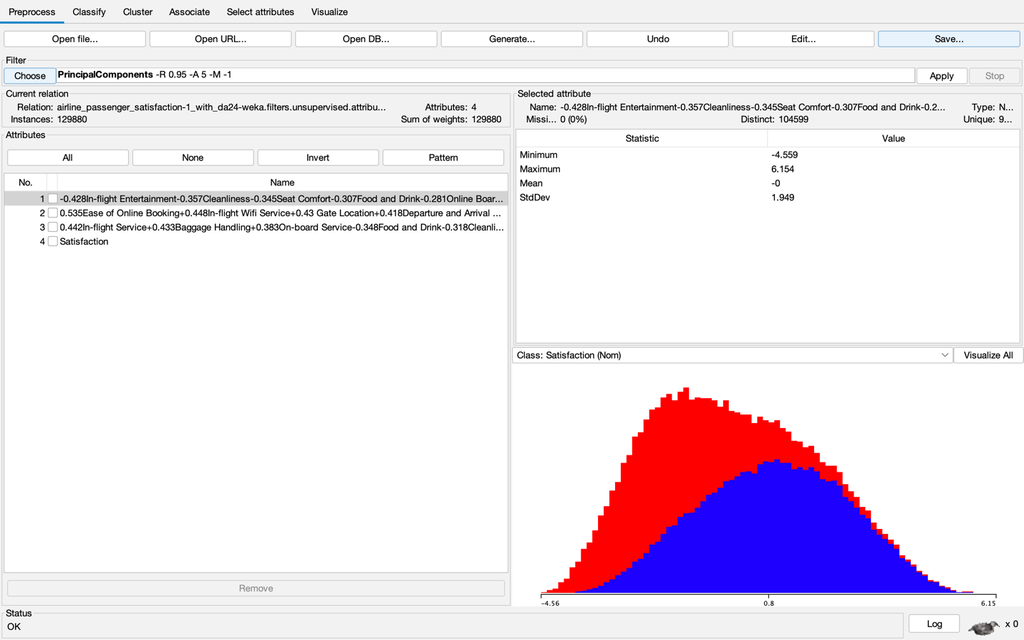

Excel was used to get the following data points as well:

- MIN Value of Attributes A10 through A23 for each instance
- MAX Value of Attributes A10 through A23 for each instance
- AVERAGE Value of Attributes A10 through A23 for each instance

Attributes A1 through A23 were dropped, and only the MIN, MAX, and AVERAGE of Attributes A10 through A13, and the Class, Satisfaction, were kept and saved as a csv file.

The csv file was loaded into Python as a Pandas DataFrame object.

Using logistic regression, the R2 values were computed for using MIN, MAX, and AVERAGE as a proxy variable for Satisfaction.

The R2 values for using the various proxy variables in this step are summarized in Table 5.1. To see the code and runs for the determining the R2 values in Step 5, please refer to the Section, “Step 5. Principal Component Analysis”, in the Colab link provided at the top of the Appendix.

## A6. Linear Regression

To see the code and runs for the determining the relationship in Step 6, please refer to the Section, “Step 6. Linear Regression”, in this document.

## A7. Data Mining to Understand Attribute Relationships Part 1

**Is satisfaction with seat comfort related (or depends on) to passenger Gender?**

Both Satisfaction with Seat Comfort and Passenger Gender are categorical variables. Therefore, the chi squared test was used to evaluate if there was a relationship between Seat comfort and Passenger Gender.

The following hypotheses were set:

- Null Hypothesis: Seat Comfort and Gender are independent to each other.
- Alternate Hypothesis: Seat Comfort and Gender are dependent on each other.

The significance threshold of 0.05 was used.

The p-value returned by the chi squared test was 1.1330e-42, which is less than the significance threshold. Therefore, we reject the null hypothesis and accept the alternate hypothesis that Seat Comfort and Gender are related to each other.

**Is satisfaction with gate location related to passenger age?**

The discretized values of age were used to answer this question. Since both Gate Location and the Discretized Age attributes are categorical, the chi squared test was used to evaluate if there was a relationship between satisfaction with gate location and passenger age.

The significance threshold of 0.05 was used.

**Do first time passengers have more or less expectations than returning customers measured in terms of overall satisfaction?**

Since both Customer Type and Overall Satisfaction attributes are categorical, the chi squared test was used to evaluate if there was a relationship between Customer Type and Overall Satisfaction.

The following hypotheses were set:

- Null Hypothesis: Customer Type and Overall Satisfaction are independent to each other.
- Alternate Hypothesis: Customer Type and Overall Satisfaction Gender are dependent on each other.

The significance threshold of 0.05 was used.

The p-value returned by the chi squared test was 0, which is less than the significance threshold. Therefore, we can reject the null hypothesis and accept the alternate hypothesis that Customer Type and Overall Satisfaction are related to each other.

**Is there a distinct (statistically significant) difference between business and personal travelers (A5) in terms of their reaction to their flights?**

Since both Type of Travel and Overall Satisfaction attributes are categorical, the chi squared test was used to evaluate if there was a relationship between satisfaction with Type of Travel and Overall Satisfaction.

The following hypotheses were set:

- Null Hypothesis: Type of Travel and Overall Satisfaction are independent to each other.
- Alternate Hypothesis: Type of Travel and Overall Satisfaction are dependent on each other.

The significance threshold of 0.05 was used.

The p-value returned by the chi squared test was 0, which is less than the significance threshold. Therefore, we can reject the null hypothesis and accept the alternate hypothesis that Type of Travel and Overall Satisfaction are related to each other.

**Is there a distinct (statistically significant) difference between business class passengers and economy passengers (A6) in terms of their reaction to satisfaction with food-and-drink?**

The following hypotheses were set:

- Null Hypothesis: Class and Satisfaction with Food and Drink are independent to each other.
- Alternate Hypothesis: Class and Satisfaction with Food and Drink are dependent on each other.

The significance threshold of 0.05 was used.

The p-value returned by the chi squared test was 0, which is less than the significance threshold. Therefore, we can reject the null hypothesis and accept the alternate hypothesis that Class and Satisfaction with Food and Drink are related to each other.

## A8. Data Mining to Understand Attribute Relationships Part 2

**Relationship between Check-In Service and Baggage Handling**

Since both Check-In Service and Baggage Handling are categorical variables, the chi-squared test was used to evaluate if there is any relationship between them.

The following null and alternate hypotheses were set:

- Null Hypothesis: Check-In Service and Baggage Handling are independent to each other.
- Alternate Hypothesis: Check-In Service and Baggage Handling are dependent on each other.

The significance level was set to 0.05.

The p-value computed from using chi squared statistic is 0, which is less than the significance level of 0.05. Therefore, we can reject the null hypothesis and accept the alternate hypothesis that Check-In Service and Baggage Handling are dependent on each other.

**Departure and Arrival Time Convenience versus Seat Comfort Effect on Overall Satisfaction**

Since the goal is to understand the relationship between two attributes and the output binary variable, logistic regression was used, similar to Step 3.

Using Logistic Regression provides us with the following values:

- Correlation coefficient for each attribute
- Z-statistic for each attribute
- P-value for each attribute

A significance threshold of 0.05 was used.

If the p-value was less than the significance threshold of 0.05, then it was determined that there was a relationship between the attribute and the output variable.

The correlation coefficient indicated the strength of the relationship between the attribute and the output variable.

*Table A8.1 Correlation Coefficient, z-statistic, and p-value for Departure and Arrival Time Convenience versus Seat Comfort Effect on Overall Satisfaction*

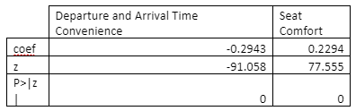